# Geocoding police reports to find the spot where the most bike crashes occur

Simon Coulombe

5 novembre 2017

```r
knitr::opts_chunk$set(message=FALSE, warning=FALSE, error= FALSE)
```

```r
library(tidyverse)
library(sf)
library(leaflet)
library(viridis)
library(htmlwidgets)
library(readr)
require(scales)
#devtools::install_github("dkahle/ggmap") # requires development version  2.7 to allow use of API key.
library(ggmap)
library(stringr)
library(forcats)
library(lubridate)
library(leaflet)
library(viridis)
library(leaflet.extras)
library(DT)

#filter by adding a city name (foundin NAME_MUNCP) or juste type "province" for the whole data set
city <- "province"

#either type "bikes" for bikes or "pedestrians" for pedestrians
type <- "bikes"   # bikes , pedestrians

download_files <- FALSE  # download files?  only do once
read_from_csv <- FALSE  # read csv and wrangle (only do once), or read pre-created rdata?
geocode <- FALSE  # geocode the data using google maps ( 50 cents per 1000), or read pre-geocoded rdata ?

#https://stackoverflow.com/questions/36175529/getting-over-query-limit-after-one-request-with-geocode
register_google(key = Sys.getenv("googlemap_api_key"),
                account_type="premium")
####### DO NOT CHANGE ANYTHING BELOW THIS LINE ################################

if(city == "province"){
  citytext <- "province de Québec"
  } else {citytext <- paste0("city of ",city)}
```

# 1 Objective

In this project, we will geocode the crash data to identify the spots where the accidents involving bikes in province. This will allow us to determine in which areas an intervention to reduce the risk to active transportation would be most useful.

# 2 Data sources

Open data about the [2011-2016 car crashes reported to the police](https://www.donneesquebec.ca/recherche/fr/dataset/rapports-d-accident) come from the province of Québec’s open data portal.  
[The data dictionary](https://saaq.gouv.qc.ca/donnees-ouvertes/rapports-accident/rapports-accident-documentation.pdf) is also available on-line.

# 3 Packages used

Data wrangling is done using packages from the `tidyverse`. Geospatial data is geocoded using the `ggmap` package and treated using `sf`.  
Data visualisations are done using `ggplot2` and `leaflet`. If I remember correctly, the `leaflet.extras` package is used to the leaflet heatmap.  
Color palettes for the maps are generated using the `viridis` package.  
Data tables are displayed using the `DT` package.

# 4 Code

The code that generated this document is located in https://raw.githubusercontent.com/SimonCoulombe/saaqmtq/master/blog_saaq.Rmd

## 4.1 Define functions, downloads files

```r
# the wrapper function automatically add lin changes to strings, allowing titles
# to fit inside ggplot
wrapper <- function(x, ...)
{
  paste(strwrap(x, ...), collapse = "\n")
}

if(download_files){
  ## crashes files
  download.file("https://saaq.gouv.qc.ca/donnees-ouvertes/rapports-accident/rapports-accident-2016.csv",
                destfile= "./data/rapports-accident-2016.csv")
  download.file("https://saaq.gouv.qc.ca/donnees-ouvertes/rapports-accident/rapports-accident-2015.csv",
                destfile= "./data/rapports-accident-2015.csv")
  download.file("https://saaq.gouv.qc.ca/donnees-ouvertes/rapports-accident/rapports-accident-2014.csv",
                destfile= "./data/rapports-accident-2014.csv")
  download.file("https://saaq.gouv.qc.ca/donnees-ouvertes/rapports-accident/rapports-accident-2013.csv",
                destfile= "./data/rapports-accident-2013.csv")
  download.file("https://saaq.gouv.qc.ca/donnees-ouvertes/rapports-accident/rapports-accident-2012.csv",
                destfile= "./data/rapports-accident-2012.csv")
  download.file("https://saaq.gouv.qc.ca/donnees-ouvertes/rapports-accident/rapports-accident-2011.csv",
                destfile= "./data/rapports-accident-2011.csv")

# table to convert municipalite code to municipalite name
# I manually created a .tsv from the table found here
#(https://www.mamrot.gouv.qc.ca/recherche-avancee/fiche/municipalite/).
download.file("https://raw.githubusercontent.com/SimonCoulombe/saaqmtq/master/data/code_to_mun.tsv",
              destfile= "./data/code_to_mun.tsv")
}
```

## 4.2 Clean data and prepare for geocoding

```r
if (read_from_csv){

accidents16 <- read_csv("./data/rapports-accident-2016.csv") %>%
  mutate(NO_ROUTE = as.numeric(NO_ROUTE), SFX_NO_CIVIQ_ACCDN= as.character(SFX_NO_CIVIQ_ACCDN))
accidents15 <- read_csv("./data/rapports-accident-2015.csv")%>%
  mutate(NO_ROUTE = as.numeric(NO_ROUTE), SFX_NO_CIVIQ_ACCDN= as.character(SFX_NO_CIVIQ_ACCDN))
accidents14 <- read_csv("./data/rapports-accident-2014.csv")%>%
  mutate(NO_ROUTE = as.numeric(NO_ROUTE), SFX_NO_CIVIQ_ACCDN= as.character(SFX_NO_CIVIQ_ACCDN))
accidents13 <- read_csv("./data/rapports-accident-2013.csv")%>%
  mutate(NO_ROUTE = as.numeric(NO_ROUTE), SFX_NO_CIVIQ_ACCDN= as.character(SFX_NO_CIVIQ_ACCDN))
accidents12 <- read_csv("./data/rapports-accident-2012.csv")%>%
  mutate(NO_ROUTE = as.numeric(NO_ROUTE), SFX_NO_CIVIQ_ACCDN= as.character(SFX_NO_CIVIQ_ACCDN))
 accidents11 <- read_csv("./data/rapports-accident-2011.csv")%>%
   mutate(NO_ROUTE = as.numeric(NO_ROUTE), SFX_NO_CIVIQ_ACCDN= as.character(SFX_NO_CIVIQ_ACCDN))

 code_to_mun <- read_tsv("./data/code_to_mun.tsv")

 accidents <- bind_rows(accidents11,accidents12, accidents13,
                  accidents14, accidents15, accidents16)  %>%
  left_join(code_to_mun %>% select(CD_MUNCP, NAME_MUNCP), by= "CD_MUNCP") %>%
  mutate(year = year(DT_ACCDN),  # I dont use isoyear because I dont want early 2011 to show up as 2010.
         week = isoweek(DT_ACCDN),
         month = month(DT_ACCDN),
         month.abb = as.factor(base::month.abb[month]) %>%
           fct_relevel("Jan", "Feb", "Mar", "Apr", "May", "Jun",
                       "Jul", "Aug", "Sep", "Oct", "Nov", "Dec"),
         monday = floor_date(DT_ACCDN, unit = "week") ) %>%
  arrange(DT_ACCDN)  %>%
  mutate(gravite = as.factor(gravite) %>% fct_relevel("Dommages matériels seulement", "Léger", "Grave", "Mortel"))  %>%
   mutate(heure = as.numeric(ifelse(heure_accdn == "Non précisé", NA, str_sub(heure_accdn,1,2) )),
          region_num = as.numeric(str_sub(REG_ADM, -3, -2))) %>%
    mutate(row_num = row_number())  %>%
    mutate(CD_ENVRN_ACCDN = fct_recode(as.factor(CD_ENVRN_ACCDN) ,
         "Scolaire"= "1",
         "Résidentiel" = "2",
         "Affaires / commercial"= "3",
         "Industriel / Manufacturier" = "4",
         "Rural" = "5",
         "Forestier" = "6",
         "Récréatif / parc / camping" = "7",
         "Autre"    = "9",
         "Non précisé" = "0")) %>%
  mutate(CD_COND_METEO =
   fct_recode(as.factor(CD_COND_METEO),
              "Clair" = "11",
              "Couvert (nuageux/sombre)" = "12",
              "Brouillard/brume "= "13",
              "Pluie/bruine"= "14",
              "Averse (pluie forte)" = "15",
              "Vent fort (pas de poudrerie, pas de pluie)"= "16",
              "Neige/grêle"= "17",
              "Poudrerie/tempête de neige"= "18",
              "Verglas"= "19",
              "Autre" = "99")) %>%
  mutate(CD_POSI_ACCDN =
           fct_recode(as.factor(CD_POSI_ACCDN),
                      "Voie réservée en service"= "01",
                      "Voie lente/voie de dépassement" = "02",
                      "Perte/gain de voie"= "03",
                      "Voie de virage à gauche dans les deux sens"= "04",
                      "Voie cyclable/chaussée désignée"= "05",
                      "Voie de circulation "= "06",
                      "Accotement (ou bord de la chaussée)"= "07",
                      "Terre-plein central ou îlot"= "08",
                      "Trottoir"= "09",
                      "Autre" = "10"))

 save(accidents, accidents16, file= "accidents.rdata")
} else load("accidents.rdata")


if (city != "province"){
  accidents <- accidents %>% filter(filter(NAME_MUNCP == city))
}

if (type == "pedestrians"){
  accidents <- accidents %>% filter(NB_VICTIMES_PIETON > 0)
} else if (type == "bikes"){
  accidents <- accidents %>% filter(nb_bicyclette > 0)
} else {stop("type must be either  pedestrians or bikes")}

accidents$RUE_ACCDNmod <- accidents$RUE_ACCDN
accidents$ACCDN_PRES_DEmod <- accidents$ACCDN_PRES_DE

# replace short street names by full name, fix a few typos.
# \\b represents the boundary of a word in regexp
accidents$RUE_ACCDNmod <- str_replace(accidents$RUE_ACCDNmod, "\\bN-D\\b", "NOTRE-DAME") # attention rouler ceci avant NORD car le - coupe le mot
accidents$RUE_ACCDNmod <- str_replace(accidents$RUE_ACCDNmod, "\\bBD\\b", "BOULEVARD")
accidents$RUE_ACCDNmod <- str_replace(accidents$RUE_ACCDNmod, "\\bCH\\b", "CHEMIN")
accidents$RUE_ACCDNmod <- str_replace(accidents$RUE_ACCDNmod, "\\bMT\\b", "MONT")
accidents$RUE_ACCDNmod <- str_replace(accidents$RUE_ACCDNmod, "\\bAV\\b", "AVENUE")
accidents$RUE_ACCDNmod <- str_replace(accidents$RUE_ACCDNmod, "\\bN\\b", "NORD")
accidents$RUE_ACCDNmod <- str_replace(accidents$RUE_ACCDNmod, "\\bS\\b", "SUD")
accidents$RUE_ACCDNmod <- str_replace(accidents$RUE_ACCDNmod, "\\bE\\b", "EST")
accidents$RUE_ACCDNmod <- str_replace(accidents$RUE_ACCDNmod, "\\bO\\b", "OUEST")
accidents$RUE_ACCDNmod <- str_replace(accidents$RUE_ACCDNmod, "\\bST\\b", "SAINT")
accidents$RUE_ACCDNmod <- str_replace(accidents$RUE_ACCDNmod, "\\bSTE\\b", "SAINTE")
accidents$RUE_ACCDNmod <- str_replace(accidents$RUE_ACCDNmod, "\\bRTE\\b", "ROUTE")
accidents$RUE_ACCDNmod <- str_replace(accidents$RUE_ACCDNmod, "\\bTSSE\\b", "TERRASSE")
accidents$RUE_ACCDNmod <- str_replace(accidents$RUE_ACCDNmod, "\\bGD\\b", "GRAND")
accidents$RUE_ACCDNmod <- str_replace(accidents$RUE_ACCDNmod, "\\bGDE\\b", "GRANDE")
accidents$RUE_ACCDNmod <- str_replace(accidents$RUE_ACCDNmod, "\\bAUT\\b", "AUTOROUTE")
accidents$RUE_ACCDNmod <- str_replace(accidents$RUE_ACCDNmod, "\\bPTE\\b", "POINTE")
accidents$RUE_ACCDNmod <- str_replace(accidents$RUE_ACCDNmod, "\\bPRDE\\b", "PROMENADE")
accidents$RUE_ACCDNmod <- str_replace(accidents$RUE_ACCDNmod, "\\bRG\\b", "RANG")
accidents$RUE_ACCDNmod <- str_replace(accidents$RUE_ACCDNmod, "\\bPR\\b", "PROMENADE")
accidents$RUE_ACCDNmod <- str_replace(accidents$RUE_ACCDNmod, "\\bAL\\b", "ALLÉE")
accidents$RUE_ACCDNmod <- str_replace(accidents$RUE_ACCDNmod, "\\bPL\\b", "PLACE")
accidents$RUE_ACCDNmod <- str_replace(accidents$RUE_ACCDNmod, "\\bCT\\b", "CÔTE")
accidents$RUE_ACCDNmod <- str_replace(accidents$RUE_ACCDNmod, "\\bMGR\\b", "MONSEIGNEUR")
accidents$RUE_ACCDNmod <- str_replace(accidents$RUE_ACCDNmod, "\\bSTIE\\b", "SORTIE")
accidents$RUE_ACCDNmod <- str_replace(accidents$RUE_ACCDNmod, "\\bENTR\\b", "ENTRÉE")
accidents$RUE_ACCDNmod <- str_replace(accidents$RUE_ACCDNmod, "\\bMTEE\\b", "MONTÉE")
accidents$RUE_ACCDNmod <- str_replace(accidents$RUE_ACCDNmod, "\\bMTE\\b", "MONTÉE")
accidents$RUE_ACCDNmod <- str_replace(accidents$RUE_ACCDNmod, "\\bVIAD\\b", "VIADUC")
accidents$RUE_ACCDNmod <- str_replace(accidents$RUE_ACCDNmod, "\\bRIV\\b", "RIVIÈRE")
accidents$RUE_ACCDNmod <- str_replace(accidents$RUE_ACCDNmod, "\\bCROIS\\b", "AND")
accidents$RUE_ACCDNmod <- str_replace(accidents$RUE_ACCDNmod, "\\bINTERSECTION\\b", "AND")
accidents$RUE_ACCDNmod <- str_replace(accidents$RUE_ACCDNmod, "\\bSERV\\b", "SERVICE")
accidents$RUE_ACCDNmod <- str_replace(accidents$RUE_ACCDNmod, "\\bFACE À\\b", "")
accidents$RUE_ACCDNmod <- str_replace(accidents$RUE_ACCDNmod, "\\bFACE AU\\b", "")
accidents$RUE_ACCDNmod <- str_replace(accidents$RUE_ACCDNmod, "\\bEN FACE\\b", "")
accidents$RUE_ACCDNmod <- str_replace(accidents$RUE_ACCDNmod, "\\bFACE\\b", "")
accidents$RUE_ACCDNmod <- str_replace(accidents$RUE_ACCDNmod, "\\bPRÈS DE\\b", "")
accidents$RUE_ACCDNmod <- str_replace(accidents$RUE_ACCDNmod, "\\bPRÈS DU\\b", "")
accidents$RUE_ACCDNmod <- str_replace(accidents$RUE_ACCDNmod, "\\bARR START\\b", "")
accidents$RUE_ACCDNmod <- str_replace(accidents$RUE_ACCDNmod, "\\bARR DU\\b", "")
accidents$RUE_ACCDNmod <- str_replace(accidents$RUE_ACCDNmod, "\\bARR DE\\b", "")
accidents$RUE_ACCDNmod <- str_replace(accidents$RUE_ACCDNmod, "\\bARR STAT\\b", "")
accidents$RUE_ACCDNmod <- str_replace(accidents$RUE_ACCDNmod, "\\bARR\\b", "")
accidents$RUE_ACCDNmod <- str_replace(accidents$RUE_ACCDNmod, "\\bOPP DU\\b", "")
accidents$RUE_ACCDNmod <- str_replace(accidents$RUE_ACCDNmod, "\\bOPP DE\\b", "")
accidents$RUE_ACCDNmod <- str_replace(accidents$RUE_ACCDNmod, "\\bOPP\\b", "")
accidents$RUE_ACCDNmod <- str_replace(accidents$RUE_ACCDNmod, "\\bQ BOURG\\b", "QUATRE-BOURGEOIS")
accidents$RUE_ACCDNmod <- str_replace(accidents$RUE_ACCDNmod, "\\bQBOURG\\b", "QUATRE-BOURGEOIS")
accidents$RUE_ACCDNmod <- str_replace(accidents$RUE_ACCDNmod, "\\bW PELLETIER\\b", "WILFRID-PELLETIER")
accidents$RUE_ACCDNmod <- str_replace(accidents$RUE_ACCDNmod, "\\bSORTIE HENRI IV NORD\\b", "HENRI IV")
```

```r
accidents$ACCDN_PRES_DEmod <- str_replace(accidents$ACCDN_PRES_DEmod, "\\bN-D\\b", "NOTRE-DAME") # attention rouler ceci avant NORD car le - coupe le mot
accidents$ACCDN_PRES_DEmod <- str_replace(accidents$ACCDN_PRES_DEmod, "\\bBD\\b", "BOULEVARD")
accidents$ACCDN_PRES_DEmod <- str_replace(accidents$ACCDN_PRES_DEmod, "\\bCH\\b", "CHEMIN")
accidents$ACCDN_PRES_DEmod <- str_replace(accidents$ACCDN_PRES_DEmod, "\\bMT\\b", "MONT")
accidents$ACCDN_PRES_DEmod <- str_replace(accidents$ACCDN_PRES_DEmod, "\\bAV\\b", "AVENUE")
accidents$ACCDN_PRES_DEmod <- str_replace(accidents$ACCDN_PRES_DEmod, "\\bN\\b", "NORD")
accidents$ACCDN_PRES_DEmod <- str_replace(accidents$ACCDN_PRES_DEmod, "\\bS\\b", "SUD")
accidents$ACCDN_PRES_DEmod <- str_replace(accidents$ACCDN_PRES_DEmod, "\\bE\\b", "EST")
accidents$ACCDN_PRES_DEmod <- str_replace(accidents$ACCDN_PRES_DEmod, "\\bO\\b", "OUEST")
accidents$ACCDN_PRES_DEmod <- str_replace(accidents$ACCDN_PRES_DEmod, "\\bST\\b", "SAINT")
accidents$ACCDN_PRES_DEmod <- str_replace(accidents$ACCDN_PRES_DEmod, "\\bSTE\\b", "SAINTE")
accidents$ACCDN_PRES_DEmod <- str_replace(accidents$ACCDN_PRES_DEmod, "\\bRTE\\b", "ROUTE")
accidents$ACCDN_PRES_DEmod <- str_replace(accidents$ACCDN_PRES_DEmod, "\\bTSSE\\b", "TERRASSE")
accidents$ACCDN_PRES_DEmod <- str_replace(accidents$ACCDN_PRES_DEmod, "\\bGD\\b", "GRAND")
accidents$ACCDN_PRES_DEmod <- str_replace(accidents$ACCDN_PRES_DEmod, "\\bGDE\\b", "GRANDE")
accidents$ACCDN_PRES_DEmod <- str_replace(accidents$ACCDN_PRES_DEmod, "\\bAUT\\b", "AUTOROUTE")
accidents$ACCDN_PRES_DEmod <- str_replace(accidents$ACCDN_PRES_DEmod, "\\bPTE\\b", "POINTE")
accidents$ACCDN_PRES_DEmod <- str_replace(accidents$ACCDN_PRES_DEmod, "\\bPRDE\\b", "PROMENADE")
accidents$ACCDN_PRES_DEmod <- str_replace(accidents$ACCDN_PRES_DEmod, "\\bRG\\b", "RANG")
accidents$ACCDN_PRES_DEmod <- str_replace(accidents$ACCDN_PRES_DEmod, "\\bPR\\b", "PROMENADE")
accidents$ACCDN_PRES_DEmod <- str_replace(accidents$ACCDN_PRES_DEmod, "\\bAL\\b", "ALLÉE")
accidents$ACCDN_PRES_DEmod <- str_replace(accidents$ACCDN_PRES_DEmod, "\\bPL\\b", "PLACE")
accidents$ACCDN_PRES_DEmod <- str_replace(accidents$ACCDN_PRES_DEmod, "\\bCT\\b", "CÔTE")
accidents$ACCDN_PRES_DEmod <- str_replace(accidents$ACCDN_PRES_DEmod, "\\bMGR\\b", "MONSEIGNEUR")
accidents$ACCDN_PRES_DEmod <- str_replace(accidents$ACCDN_PRES_DEmod, "\\bSTIE\\b", "SORTIE")
accidents$ACCDN_PRES_DEmod <- str_replace(accidents$ACCDN_PRES_DEmod, "\\bENTR\\b", "ENTRÉE")
accidents$ACCDN_PRES_DEmod <- str_replace(accidents$ACCDN_PRES_DEmod, "\\bMTEE\\b", "MONTÉE")
accidents$ACCDN_PRES_DEmod <- str_replace(accidents$ACCDN_PRES_DEmod, "\\bMTE\\b", "MONTÉE")
accidents$ACCDN_PRES_DEmod <- str_replace(accidents$ACCDN_PRES_DEmod, "\\bVIAD\\b", "VIADUC")
accidents$ACCDN_PRES_DEmod <- str_replace(accidents$ACCDN_PRES_DEmod, "\\bRIV\\b", "RIVIÈRE")
accidents$ACCDN_PRES_DEmod <- str_replace(accidents$ACCDN_PRES_DEmod, "\\bCROIS\\b", "AND")
accidents$ACCDN_PRES_DEmod <- str_replace(accidents$ACCDN_PRES_DEmod, "\\bINTERSECTION\\b", "AND")
accidents$ACCDN_PRES_DEmod <- str_replace(accidents$ACCDN_PRES_DEmod, "\\bSERV\\b", "SERVICE")
accidents$ACCDN_PRES_DEmod <- str_replace(accidents$ACCDN_PRES_DEmod, "\\bFACE À\\b", "")
accidents$ACCDN_PRES_DEmod <- str_replace(accidents$ACCDN_PRES_DEmod, "\\bFACE AU\\b", "")
accidents$ACCDN_PRES_DEmod <- str_replace(accidents$ACCDN_PRES_DEmod, "\\bEN FACE\\b", "")
accidents$ACCDN_PRES_DEmod <- str_replace(accidents$ACCDN_PRES_DEmod, "\\bFACE\\b", "")
accidents$ACCDN_PRES_DEmod <- str_replace(accidents$ACCDN_PRES_DEmod, "\\bPRÈS DE\\b", "")
accidents$ACCDN_PRES_DEmod <- str_replace(accidents$ACCDN_PRES_DEmod, "\\bPRÈS DU\\b", "")
accidents$ACCDN_PRES_DEmod <- str_replace(accidents$ACCDN_PRES_DEmod, "\\bARR START\\b", "")
accidents$ACCDN_PRES_DEmod <- str_replace(accidents$ACCDN_PRES_DEmod, "\\bARR DU\\b", "")
accidents$ACCDN_PRES_DEmod <- str_replace(accidents$ACCDN_PRES_DEmod, "\\bARR DE\\b", "")
accidents$ACCDN_PRES_DEmod <- str_replace(accidents$ACCDN_PRES_DEmod, "\\bARR STAT\\b", "")
accidents$ACCDN_PRES_DEmod <- str_replace(accidents$ACCDN_PRES_DEmod, "\\bARR\\b", "")
accidents$ACCDN_PRES_DEmod <- str_replace(accidents$ACCDN_PRES_DEmod, "\\bOPP DU\\b", "")
accidents$ACCDN_PRES_DEmod <- str_replace(accidents$ACCDN_PRES_DEmod, "\\bOPP DE\\b", "")
accidents$ACCDN_PRES_DEmod <- str_replace(accidents$ACCDN_PRES_DEmod, "\\bOPP\\b", "")
accidents$ACCDN_PRES_DEmod <- str_replace(accidents$ACCDN_PRES_DEmod, "\\bQ BOURG\\b", "QUATRE-BOURGEOIS")
accidents$ACCDN_PRES_DEmod <- str_replace(accidents$ACCDN_PRES_DEmod, "\\bQBOURG\\b", "QUATRE-BOURGEOIS")
accidents$ACCDN_PRES_DEmod <- str_replace(accidents$ACCDN_PRES_DEmod, "\\bW PELLETIER\\b", "WILFRID-PELLETIER")
accidents$ACCDN_PRES_DEmod <- str_replace(accidents$ACCDN_PRES_DEmod, "\\bSORTIE HENRI IV NORD\\b", "HENRI IV")

## create a location variable that is understandable by google maps

accidents <- accidents %>%
 mutate(location =
           case_when(
             !is.na(NO_CIVIQ_ACCDN) & !is.na(RUE_ACCDNmod) ~
               str_c(str_replace_na(as.numeric(NO_CIVIQ_ACCDN), ""),
                     " ",
                     str_replace_na(RUE_ACCDNmod, "")," ",
                     str_replace_na(NAME_MUNCP,""), ", QC, Canada"),
             TP_REPRR_ACCDN==1 & !is.na(RUE_ACCDNmod) & !is.na(ACCDN_PRES_DEmod) ~
               str_c(str_replace_na(RUE_ACCDNmod, ""),
                     " and ",
                     str_replace_na(ACCDN_PRES_DEmod, "")," ",
                     str_replace_na(NAME_MUNCP,""), ", QC, Canada"),
             TP_REPRR_ACCDN==1 & (!is.na(RUE_ACCDNmod) | !is.na(ACCDN_PRES_DEmod)) ~
               str_c(str_replace_na(RUE_ACCDNmod, ""),
                     str_replace_na(ACCDN_PRES_DEmod, "")," ",
                     str_replace_na(NAME_MUNCP,""),", QC, Canada"),
             !is.na(RUE_ACCDNmod) & !is.na(ACCDN_PRES_DEmod) ~
               str_c(str_replace_na(RUE_ACCDNmod, ""),
                     " and ",
                     str_replace_na(ACCDN_PRES_DEmod, "")," ",
                     str_replace_na(NAME_MUNCP,""),", QC, Canada"),
             str_detect(toupper(RUE_ACCDNmod), " ET ") ~
               str_c(RUE_ACCDNmod,
                     " ",
                     str_replace_na(NAME_MUNCP,""),", QC, Canada"),
             str_detect(toupper(ACCDN_PRES_DEmod), " ET ") ~
               str_c(ACCDN_PRES_DEmod,
                     " ",
                     str_replace_na(NAME_MUNCP,""),", QC, Canada")
           ))
```

Here is a snapshot of the data as it was received

```r
datatable(data =  accidents16 %>% slice(1:10),

          rownames = F,
          options = list(dom = 't', ordering = F, pageLength=10) ,
          caption = "Snapshot of data as downloaded")
```

| an | NO_SEQ_COLL | DT_ACCDN | heure_accdn | JR_SEMN_ACCDN | gravite | NB_MORTS | NB_BLESSES_GRAVES | NB_BLESSES_LEGERS | NB_VICTIMES_TOTAL | NB_VEH_IMPLIQUES_ACCDN | NB_DECES_PIETON | NB_BLESSES_PIETON | NB_VICTIMES_PIETON | NB_DECES_MOTO | NB_BLESSES_MOTO | NB_VICTIMES_MOTO | NB_DECES_VELO | NB_BLESSES_VELO | NB_VICTIMES_VELO | CD_MUNCP | REG_ADM | MRC | NO_CIVIQ_ACCDN | SFX_NO_CIVIQ_ACCDN | RUE_ACCDN | TP_REPRR_ACCDN | ACCDN_PRES_DE | NO_ROUTE | CD_PNT_CDRNL_ROUTE | … |
| --- | --- | --- | --- | --- | --- | --- | --- | --- | --- | --- | --- | --- | --- | --- | --- | --- | --- | --- | --- | --- | --- | --- | --- | --- | --- | --- | --- | --- | --- | --- |
| 2016 | 2016 _ 1 | 2016-12-24 | 16:00:00-16:59:00 | SA | Dommages matériels seulement | 0 | 0 | 0 | 0 | 2 | 0 | 0 | 0 | 0 | 0 | 0 | 0 | 0 | 0 | 77043 | Laurentides(15) | Les Pays-d'en-Haut (77 ) |  |  |  | 1 | JEAN ADAM ET TURCOT |  |  | … |
| 2016 | 2016 _ 2 | 2016-12-01 | 02:00:00-02:59:00 | JE | Dommages matériels seulement | 0 | 0 | 0 | 0 | 1 | 0 | 0 | 0 | 0 | 0 | 0 | 0 | 0 | 0 | 23027 | Capitale-Nationale(03) | Québec (23 ) |  |  | ARGON | 1 | CUIVRE |  |  | … |
| 2016 | 2016 _ 3 | 2016-01-15 | 11:00:00-11:59:00 | VE | Dommages matériels seulement | 0 | 0 | 0 | 0 | 1 | 0 | 0 | 0 | 0 | 0 | 0 | 0 | 0 | 0 | 58227 | Montérégie(16) | Longueuil (58 ) |  |  | VOLTA | 1 | VOIE FERR |  |  | … |
| 2016 | 2016 _ 4 | 2016-01-20 | 21:00:00-21:59:00 | ME | Dommages matériels seulement | 0 | 0 | 0 | 0 | 1 | 0 | 0 | 0 | 0 | 0 | 0 | 0 | 0 | 0 | 66087 | Montréal(06) | Montréal (66 ) |  |  | AV MARCHALLS | 2 | GARE VIA RAIL DORVAL |  |  | … |
| 2016 | 2016 _ 5 | 2016-01-26 | 14:00:00-14:59:00 | MA | Dommages matériels seulement | 0 | 0 | 0 | 0 | 1 | 0 | 0 | 0 | 0 | 0 | 0 | 0 | 0 | 0 | 66023 | Montréal(06) | Montréal (66 ) | 04500 |  | HICKMORE VILLE ST LAURENT |  |  |  |  | … |
| 2016 | 2016 _ 6 | 2016-03-04 | 18:00:00-18:59:00 | VE | Dommages matériels seulement | 0 | 0 | 0 | 0 | 2 | 0 | 0 | 0 | 0 | 0 | 0 | 0 | 0 | 0 | 60028 | Lanaudière(14) | L'Assomption (60 ) |  |  | RG LES SULPICIENS | 2 | PASSAGE A NIV CN |  |  | … |
| 2016 | 2016 _ 7 | 2016-04-07 | 13:00:00-13:59:00 | JE | Dommages matériels seulement | 0 | 0 | 0 | 0 | 2 | 0 | 0 | 0 | 0 | 0 | 0 | 0 | 0 | 0 | 66023 | Montréal(06) | Montréal (66 ) |  |  | DE MEAUX | 1 | J B MARTINEAU |  |  | … |
| 2016 | 2016 _ 8 | 2016-06-03 | 10:00:00-10:59:00 | VE | Dommages matériels seulement | 0 | 0 | 0 | 0 | 2 | 0 | 0 | 0 | 0 | 0 | 0 | 0 | 0 | 0 | 66023 | Montréal(06) | Montréal (66 ) | 08050 |  | BD CAVENDISH | 2 | VOIE FERR |  |  | … |
| 2016 | 2016 _ 9 | 2016-09-20 | 12:00:00-12:59:00 | MA | Dommages matériels seulement | 0 | 0 | 0 | 0 | 1 | 0 | 0 | 0 | 0 | 0 | 0 | 0 | 0 | 0 | 66032 | Montréal(06) | Montréal (66 ) |  |  | VIAD AV GREENE COIN AV PROSPECT | 2 | SOUS VIAD DU CANADIEN PACIFIC |  |  | … |
| 2016 | 2016 _ 10 | 2016-10-09 | 12:00:00-12:59:00 | DI | Dommages matériels seulement | 0 | 0 | 0 | 0 | 2 | 0 | 0 | 0 | 0 | 0 | 0 | 0 | 0 | 0 | 66023 | Montréal(06) | Montréal (66 ) |  |  |  | 2 | VOIE FERR PRES SPA BOTA BOTA |  |  | … |

When preparing the car crash (“accidents”) data, we generate a factor variable of the seriousness (“gravité”) of the crash, from least serious to most serious.

| French | English |
| --- | --- |
| Dommages matériels seulement | fender bender |
| Léger | minor injuries |
| Grave | major injuries |
| Mortel | deadly |

To convert the municipality codes to names, I created a tab-separated file from this [tablea](https://www.mamrot.gouv.qc.ca/recherche-avancee/fiche/municipalite/) on the provincial government website.

The dataset contains multiple variables related to the crash location, but it doesnt include the latitude and longitude of the crash. We will need to create a string variable (I called it “location”) that will be passed to the google maps API so that it can return us a latitude and a longitude.

The geographical variables are as follow. They are never all filled.

- “NO_CIVIQ_ACCDN” , the street civic number
- “SFX_NO_CIVIQ_ACCDN”, a suffix to the street number
- “RUE_ACCDN”, the road name
- “CD_MUNCP”, the city code. Here is a dictionnary to convert city code to name.
- “NO_ROUTE” is the road number where the accident happened (numbered roads are typically highways). This seems to be used as a alternative to the road name RUE_ACCDN.
- “CD_PNT_CDRNL_ROUTE” is the direction (North, South, East, West (Ouest) ) travelled on the road/highway.
- “BORNE_KM_ACCDN” is the milestone number (used on highways and northern gravel roads)

They also use landmarks (road crossings, etc..) to help locate the accident:

- TP_REPRR_ACCDN is the type of landmark.
  - 1 means the intersection of two roads,
  - 2 " means “other landmark”
  - 0 means the type is not specified.
- “ACCDN_PRES_DE” is the landmark that the type refers to. It can be the road that intersects the road named under “RUE_ACCDN”, a bridge, a school name, etc.
- “NB_METRE_DIST_ACCD” is the distance in meters between the landmark and the accident.
- “CD_PNT_CDRNL_REPRR” is the direction (North,South, East, Ouest) from the landmark to the accident.

Since most crashes involving pedestrians and bikes are located in the cities, the data typically contains the street civic number + street name or the name of the two streets at the road crossing. I didnt try to geocode the more complicated cases involving the milestone number.

## 4.3 Geocoding using `ggmap`

```r
geocode_this <- accidents

## drop the  records for which I didnt generate a "location" string"
drop_no_word_location <- geocode_this %>% filter(is.na(location))

# geocode_this is down to 900 obs
geocode_this  <-geocode_this %>% filter(!is.na(location))

#https://stackoverflow.com/questions/36175529/getting-over-query-limit-after-one-request-with-geocode
# geocode using google maps api
if(geocode){
geo <-ggmap::geocode(location = geocode_this %>% pull(location), output = "latlon", source= "google")
save(geocode_this, geo, file= paste0("geo_",city,"_",type,".rdata"))
} else {load(paste0("geo_",city,"_",type,".rdata"))}


geocode_this$lon <- geo$lon
geocode_this$lat <- geo$lat

# drop those that couldnt be successfully geocoded
# geocode_this is down to N obs
drop_no_latlon_location <- geocode_this %>% filter(is.na(lat))
geocode_this <- geocode_this %>% filter(!is.na(lat) | !is.na(lon))
```

I used the `ggmap`package to geocode the car crashes through the google maps API. The free version of the API is limited to 2 500 calls per day, so I had to get a premium API key. This project didnt cost me anything since I had some google credit from I dont know when.

11639 crashes involving bikes occurred in province de Québec between 2011 and 2016.

I didnt attempt to geocode 213 of them because I wasnt able to generate a satisfying “location” string. These crashes are listed in the appendix.

The API couldnt return a latitude/longitude for 392 of the 11426 that I tried to geocode. These are also listed in the appendix.

# 5 Exploratory data analysis (pre-geocoding)

I generate some tables and graphs here before moving toward our goal of listing the locations with the most crashes. The goal is the make sure that the data is sane and maybe to generate additional questions for future projects.

## 5.1 Crashes by year

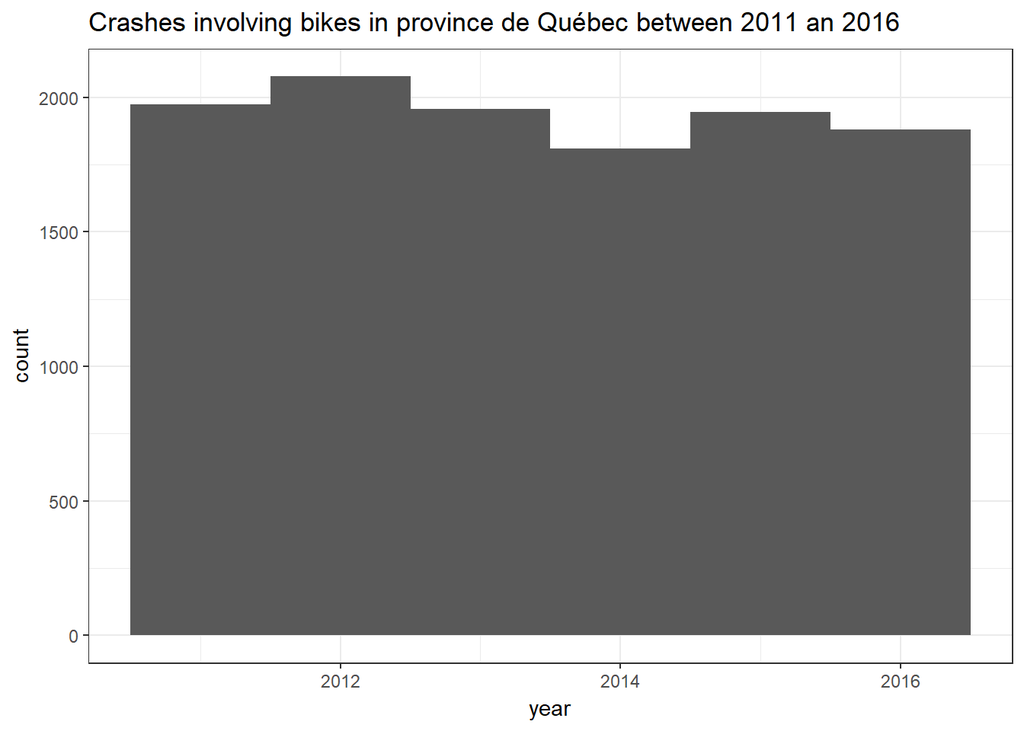

```r
accidents %>% ggplot(aes(x=year))+ geom_histogram(binwidth = 1)+
  ggtitle(wrapper(paste0("Crashes involving ", type, " in ", citytext, " between 2011 an 2016"),
                  width = 70))+
  theme_bw()
```

## 5.2 Crashes by month of the year

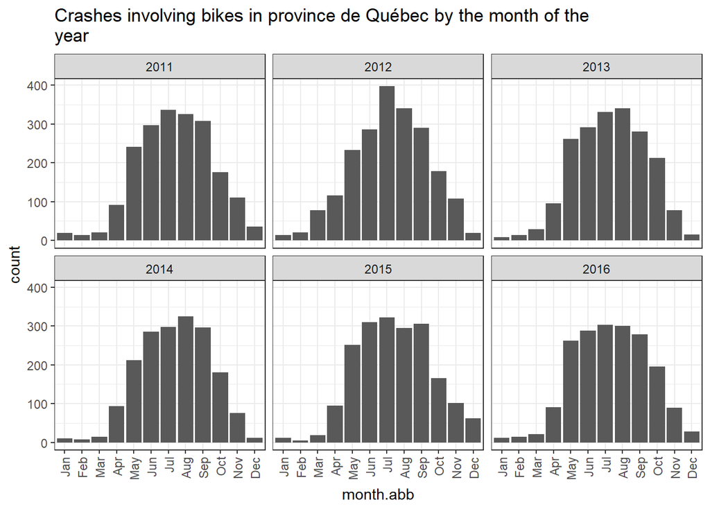

```r
ggplot(accidents,aes(x = month.abb)) +
    geom_histogram(binwidth=1, stat="count")+
  ggtitle(wrapper(paste0("Crashes involving ", type, " in ", citytext, " by the month of the year"),
                  width=70))+
  facet_wrap(~ year)+
  theme_bw() +
  theme(axis.text.x = element_text(angle = 90, vjust = 0.5, hjust=1))
```

## 5.3 Crashes by time of the day

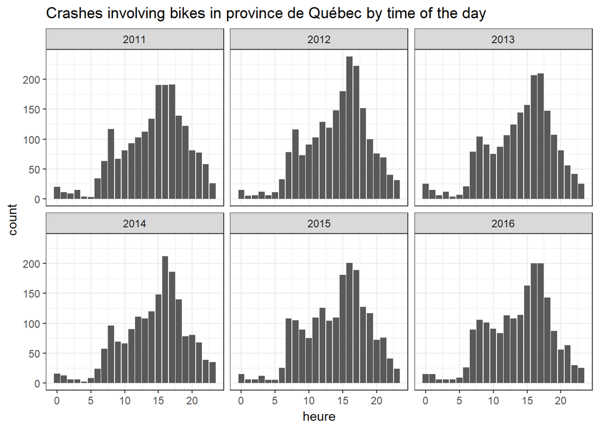

```r
ggplot(accidents,aes(x = heure)) +
    geom_bar()+
  ggtitle(wrapper(paste0("Crashes involving  ", type, " in ", citytext, " by time of the day"), width=70))+
  facet_wrap(~ year)+
  theme_bw()
```

## 5.4 Crashes by weather conditions

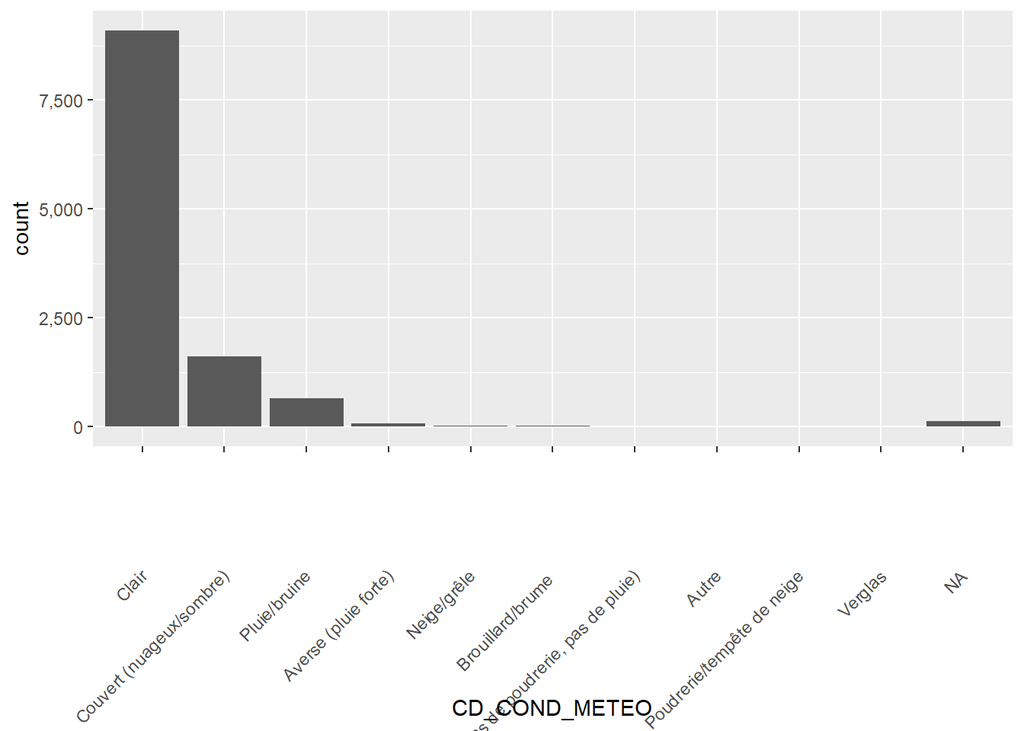

```r
accidents %>%
  mutate(CD_COND_METEO = CD_COND_METEO %>% fct_infreq() )%>%
ggplot()+
  geom_bar(mapping = aes(x=CD_COND_METEO))+
  theme(axis.text.x = element_text(angle = 45, vjust = 0.5, hjust=1))+
   scale_y_continuous(labels = comma)
```

## 5.5 Crashes by administrative area

```r
liste <- accidents %>% count(REG_ADM) %>% arrange(desc(n))   %>% select(REG_ADM) %>% mutate(rang = row_number())

datatable(data =  accidents %>%
            inner_join(liste) %>%
            count(region_num,REG_ADM,year) %>%
            spread(key=year, value=n) %>%
            arrange(region_num) %>%
            rename(`Région administrative` = REG_ADM) %>%
            select(-region_num),

          rownames = F,
          options = list(dom = 't', ordering = F, pageLength=17) ,
          caption = paste0("Crashes involving ", type,"  in each administrative area between 2011 and 2016"))
```

| Région administrative | 2011 | 2012 | 2013 | 2014 | 2015 | 2016 |
| --- | --- | --- | --- | --- | --- | --- |
| Bas-Saint-Laurent(01) | 27 | 30 | 21 | 27 | 33 | 21 |
| Saguenay/-Lac-Saint-Jean(02) | 40 | 49 | 39 | 21 | 29 | 34 |
| Capitale-Nationale(03) | 185 | 203 | 180 | 161 | 196 | 138 |
| Mauricie(04) | 71 | 70 | 76 | 50 | 56 | 51 |
| Estrie(05) | 39 | 51 | 55 | 43 | 45 | 40 |
| Montréal(06) | 696 | 799 | 774 | 691 | 788 | 774 |
| Outaouais(07) | 79 | 78 | 61 | 77 | 78 | 79 |
| Abitibi-Témiscamingue(08) | 27 | 18 | 20 | 12 | 25 | 23 |
| Côte-Nord(09) | 13 | 12 | 8 | 14 | 13 | 10 |
| Nord-du-Québec(10) |  | 5 | 5 | 2 | 2 | 1 |

[output cut: 7 more lines]

## 5.6 Crashes by city (top 10)

```r
liste <- accidents %>% count(NAME_MUNCP) %>% arrange(desc(n)) %>% top_n(10)  %>% select(NAME_MUNCP) %>% mutate(rang = row_number())

datatable(data =  accidents %>%
            inner_join(liste) %>%
            count(rang, NAME_MUNCP,year) %>%
            spread(key=year, value=n) %>%
            rename(`Municipalité` = NAME_MUNCP),

          rownames = F,
          options = list(dom = 't', ordering = F, pageLength=10) ,
          caption = paste0("Crashes involving ", type," by ciy, 2011 to 2016"))
```

| rang | Municipalité | 2011 | 2012 | 2013 | 2014 | 2015 | 2016 |
| --- | --- | --- | --- | --- | --- | --- | --- |
| 1 | Montréal | 651 | 750 | 727 | 651 | 747 | 735 |
| 2 | Québec | 162 | 176 | 156 | 143 | 163 | 110 |
| 3 | Longueuil | 90 | 74 | 73 | 79 | 75 | 60 |
| 4 | Laval | 71 | 83 | 63 | 68 | 82 | 74 |
| 5 | Gatineau | 72 | 73 | 55 | 70 | 74 | 67 |
| 6 | Trois-Rivières | 49 | 51 | 49 | 37 | 32 | 31 |
| 7 | Saint-Jean-sur-Richelieu | 34 | 36 | 43 | 30 | 30 | 26 |
| 8 | Sherbrooke | 24 | 36 | 37 | 26 | 25 | 25 |
| 9 | Lévis | 34 | 25 | 22 | 16 | 29 | 24 |
| 10 | Drummondville | 21 | 15 | 21 | 32 | 26 | 25 |

[output cut: 1 more lines]

## 5.7 Crashes by seriousness

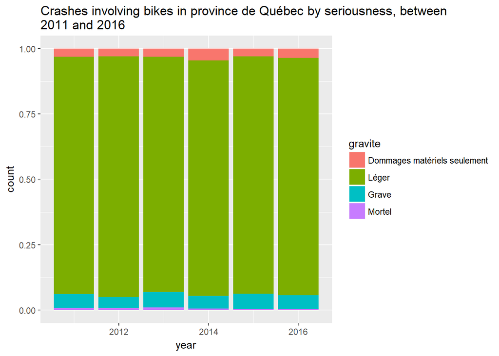

```r
ggplot(accidents,aes(x = year, fill= gravite)) +
    geom_bar(position = "fill")+
  ggtitle(wrapper(paste0("Crashes involving ", type, " in ", citytext, " by seriousness, between 2011 and 2016"), width=70))
```

## 5.8 List of deadly crashes

```r
datatable(data =  accidents %>% filter(gravite== "Mortel") %>% select(DT_ACCDN, gravite, location, NAME_MUNCP, NO_CIVIQ_ACCDN, RUE_ACCDN, ACCDN_PRES_DE, TP_REPRR_ACCDN, ACCDN_PRES_DEmod, ACCDN_PRES_DE)  %>%
            arrange(DT_ACCDN),

          rownames = F,
          options = list(dom = 'tp', ordering = F, pageLength=11) ,
          caption = paste0("List of the ", accidents   %>% filter(gravite == "Mortel") %>% tally(), " deadly crashes involving ", type," in ", citytext, ", 2011 to 2016"))
```

| DT_ACCDN | gravite | location | NAME_MUNCP | NO_CIVIQ_ACCDN | RUE_ACCDN | ACCDN_PRES_DE | TP_REPRR_ACCDN | ACCDN_PRES_DEmod |
| --- | --- | --- | --- | --- | --- | --- | --- | --- |
| 2011-01-18 | Mortel | CHEMIN CITE DES JEUNES and CHEMIN SAINT EMMANUEL Saint-Clet, QC, Canada | Saint-Clet |  | CH CITE DES JEUNES | CH ST EMMANUEL | 1 | CHEMIN SAINT EMMANUEL |
| 2011-06-06 | Mortel | SALABERRY and PASTEUR Montréal, QC, Canada | Montréal |  | SALABERRY | PASTEUR | 1 | PASTEUR |
| 2011-06-17 | Mortel | CHAMBLY ET CHURCHILL Longueuil, QC, Canada | Longueuil |  | CHAMBLY ET CHURCHILL |  | 1 |  |
| 2011-07-11 | Mortel | 45 WATER Danville, QC, Canada | Danville | 00045 | WATER |  |  |  |
| 2011-07-12 | Mortel | 5051 INDUSTRIEL Montréal, QC, Canada | Montréal | 05051 | INDUSTRIEL FACE | LAMOUREUX | 1 | LAMOUREUX |
| 2011-07-17 | Mortel | 1341 NOTRE-DAME Saint-Rémi, QC, Canada | Saint-Rémi | 01341 | N-D | RG ST ANTOINE | 1 | RANG SAINT ANTOINE |
| 2011-07-23 | Mortel | CHEMIN KNOWLTON and MAPLE Lac-Brome, QC, Canada | Lac-Brome |  | CH KNOWLTON | MAPLE | 1 | MAPLE |
| 2011-08-04 | Mortel | 91 5E AVENUE Saint-Gabriel-de-Valcartier, QC, Canada | Saint-Gabriel-de-Valcartier | 00091 | 5E AV |  |  |  |
| 2011-08-09 | Mortel | FRONTENAC and NOTRE-DAME Montréal, QC, Canada | Montréal |  | FRONTENAC | N-D | 1 | NOTRE-DAME |
| 2011-08-09 | Mortel |  | Saint-Apollinaire |  | RG BOIS FRANC O DU 648 |  | 2 |  |

[output cut: 69 more lines]

# 6 Résults - geocoded data

The rest of the analysis only involves the crashes that were successfully geocoded.

## 6.1 Top 10 locations with the most crashes

The table below shoes the top 10 of the locations with the most crashes involving bikes in province de Québec between 2011 and 2016.

If we used the data from the whole province then we generate a top 10 for each cities below.

```r
# add count variable, grouping by lat-long
geocode_this <- geocode_this  %>% group_by(lat,lon) %>% mutate(accidents = n()) %>% arrange(desc(accidents), lat, lon, DT_ACCDN) %>% ungroup()
```

[output not shown]

```r
input <- geocode_this %>% count(NAME_MUNCP) %>% arrange(desc(n)) %>% top_n(10)
```

```r
# https://stackoverflow.com/questions/39732560/why-does-datatable-not-print-when-looping-in-rmarkdown
for (i in seq(nrow(input))) {
  current <- input[i, ]
  cat(paste("\n\n### city of ", current$NAME_MUNCP, "##\n"))

worst10sub <- geocode_this %>%  filter(NAME_MUNCP == current$NAME_MUNCP)  %>% group_by(lat,lon) %>% slice(1:1) %>% ungroup() %>% select(accidents, location, lon, lat)  %>% arrange(desc(accidents))   %>% slice(1:10)
print( htmltools::tagList(datatable(data = worst10sub  %>% select(-lat, -lon),
          rownames = F,
          options = list(dom = 't', ordering = F, pageLength=10) ,
          caption = paste0("Top  10 locations with the most geocoded crashes involving ", type, " for the city of ", current$NAME_MUNCP," between 2011 and 2016)"))
))
}
```

### 6.1.1 city of Montréal

| accidents | location |
| --- | --- |
| 18 | CREMAZIE and CHRISTOPHE COLOMB Montréal, QC, Canada |
| 16 | DE MAISONNEUVE and DUFORT Montréal, QC, Canada |
| 16 | RACHEL and SAINT DENIS Montréal, QC, Canada |
| 15 | DES PINS and SAINT URBAIN Montréal, QC, Canada |
| 13 | DE MAISONNEUVE OUEST and ATWATER Montréal, QC, Canada |
| 13 | SAINT URBAIN and MAISONNEUVE Montréal, QC, Canada |
| 12 | MAISONNEUVE OUEST and LAMBERT CLOSSE Montréal, QC, Canada |
| 12 | MAISONNEUVE OUEST and MCGILL COLLEGE Montréal, QC, Canada |
| 12 | RENE LEVESQUE ET PAPINEAU Montréal, QC, Canada |
| 11 | DE MAISONNEUVE OUEST and STANLEY Montréal, QC, Canada |

### 6.1.2 city of Québec

| accidents | location |
| --- | --- |
| 6 | 3E AVENUE and 4E RUE Québec, QC, Canada |
| 5 | HENRI IV and QUATRE BOURGEOIS Québec, QC, Canada |
| 5 | HOLLAND and RENE LEVESQUE OUEST Québec, QC, Canada |
| 5 | BOULEVARD WILFRID HAMEL and BOULEVARD PIERRE BERTRAND Québec, QC, Canada |
| 5 | CHEMIN DE LA CANARDIERE and BOULEVARD HENRI BOURASSA Québec, QC, Canada |
| 4 | EGLISES and HOCHELAGA Québec, QC, Canada |
| 4 | MARIE DE L INCARNATION and BOULEVARD CHAREST OUEST Québec, QC, Canada |
| 4 | LANGELIER ET SAINT JOSEPH Québec, QC, Canada |
| 4 | HENRI BOURASSA and 18E RUE Québec, QC, Canada |
| 4 | 4E AVENUE and DES PEUPLIERS EST Québec, QC, Canada |

### 6.1.3 city of Longueuil

| accidents | location |
| --- | --- |
| 7 | CHEMIN CHAMBLY and JACQUES CARTIER OUEST Longueuil, QC, Canada |
| 5 | JOLIETTE and CURE POIRIER OUEST Longueuil, QC, Canada |
| 4 | TASCHEREAU and REGENT Longueuil, QC, Canada |
| 4 | MAISONNEUVE and JACQUES CARTIER OUEST Longueuil, QC, Canada |
| 3 | GRANDE ALLÉE and GAETAN BOUCHER Longueuil, QC, Canada |
| 3 | NORMANDIE and LORAINE Longueuil, QC, Canada |
| 3 | JEANNETTE and SAINT GEORGES Longueuil, QC, Canada |
| 3 | NOTRE-DAME and LOGAN Longueuil, QC, Canada |
| 3 | NOBERT and VICTORIA Longueuil, QC, Canada |
| 3 | JACQUES CARTIER OUEST ET DESCHAMPS Longueuil, QC, Canada |

### 6.1.4 city of Laval

| accidents | location |
| --- | --- |
| 4 | BOULEVARD CURE LABELLE and BOULEVARD SAMSON Laval, QC, Canada |
| 4 | BOULEVARD LEVESQUE EST and MONTÉE SAINT FRANCOIS Laval, QC, Canada |
| 3 | BOULEVARD DU SOUVENIR and BOULEVARD ARMAND FRAPPIER Laval, QC, Canada |
| 3 | BOULEVARD LAURENTIDES and BOULEVARD CARTIER Laval, QC, Canada |
| 3 | CURE LABELLE and SAINT ELZEAR Laval, QC, Canada |
| 3 | CORBUSIER and SAINT ELZEAR OUEST Laval, QC, Canada |
| 3 | CORBUSIER and DAGENAIS Laval, QC, Canada |
| 3 | CURE LABELLE and MARC AURELE FORTIN Laval, QC, Canada |
| 3 | BOULEVARD RENE LAENNEC and DAGENAIS Laval, QC, Canada |
| 3 | 6180 LEVESQUE EST Laval, QC, Canada |

### 6.1.5 city of Gatineau

| accidents | location |
| --- | --- |
| 8 | EDDY and LAURIER Gatineau, QC, Canada |
| 7 | BOULEVARD SAINT JOSEPH and BOULEVARD DES ALLUMETIERES Gatineau, QC, Canada |
| 7 | BOULEVARD MALONEY and MAIN Gatineau, QC, Canada |
| 6 | LAURIER and BOULEVARD DES ALLUMETIERES Gatineau, QC, Canada |
| 4 | MONTCALM and HANSON Gatineau, QC, Canada |
| 4 | SAINT REDEMPTEUR and BOULEVARD ALLUMETTIERES Gatineau, QC, Canada |
| 4 | BOULEVARD MAISONNEUVE and BOULEVARD DES ALLUMETTIERES Gatineau, QC, Canada |
| 4 | BOULEVARD MONTCLAIR and BERRI Gatineau, QC, Canada |
| 4 | BOULEVARD GREBER and BOULEVARD MALONEY OUEST Gatineau, QC, Canada |
| 3 | PRINCIPALE and AVENUE FRANK ROBINSON Gatineau, QC, Canada |

### 6.1.6 city of Trois-Rivières

| accidents | location |
| --- | --- |
| 6 | AVENUE DES DRAVEURS and BOULEVARD DU SAINT MAURICE Trois-Rivières, QC, Canada |
| 4 | BONAVENTURE and ROYALE Trois-Rivières, QC, Canada |
| 4 | BOULEVARD DU SAINT MAURICE ET ST PAUL Trois-Rivières, QC, Canada |
| 3 | ROYALE and SAINT GEORGE Trois-Rivières, QC, Canada |
| 3 | BARKOFF and DES ORMEAUX Trois-Rivières, QC, Canada |
| 3 | THIBEAU and BERLINGUET Trois-Rivières, QC, Canada |
| 3 | CHAMBERLAND and THIBEAU Trois-Rivières, QC, Canada |
| 2 | COTE RICHELIEU and BOULEVARD SAINT JEAN Trois-Rivières, QC, Canada |
| 2 | SAINT OLIVIER ET LAVERENDRYE Trois-Rivières, QC, Canada |
| 2 | DE LA VERENDRYE and SAINT DENIS Trois-Rivières, QC, Canada |

### 6.1.7 city of Saint-Jean-sur-Richelieu

| accidents | location |
| --- | --- |
| 6 | 400 BOULEVARD SEMINAIRE Saint-Jean-sur-Richelieu, QC, Canada |
| 6 | SEMINAIRE and SAINT LOUIS Saint-Jean-sur-Richelieu, QC, Canada |
| 5 | SAINT JACQUES and DU QUAI Saint-Jean-sur-Richelieu, QC, Canada |
| 4 | SAINT JACQUES and LAURIER Saint-Jean-sur-Richelieu, QC, Canada |
| 3 | 5E AVENUE and MARIA BOIVIN Saint-Jean-sur-Richelieu, QC, Canada |
| 3 | 172 9E AVENUE Saint-Jean-sur-Richelieu, QC, Canada |
| 2 | JACQUES CARTIER SUD and CARILLON Saint-Jean-sur-Richelieu, QC, Canada |
| 2 | 320 JACQUES CARTIER SUD Saint-Jean-sur-Richelieu, QC, Canada |
| 2 | SEMINAIRE NORD and SAINT GEORGES Saint-Jean-sur-Richelieu, QC, Canada |
| 2 | SAINT JACQUES and BOULEVARD DU SEMINAIRE Saint-Jean-sur-Richelieu, QC, Canada |

### 6.1.8 city of Sherbrooke

| accidents | location |
| --- | --- |
| 4 | TERRILL and CHICOYNE Sherbrooke, QC, Canada |
| 3 | KING EST and BOULEVARD SAINT FRANCOIS Sherbrooke, QC, Canada |
| 3 | 12EM AVENUE NORD and KING EST Sherbrooke, QC, Canada |
| 2 | UNIVERSITE and LAFERRIERE Sherbrooke, QC, Canada |
| 2 | GALT ET PRUNIER Sherbrooke, QC, Canada |
| 2 | 3065 KING OUEST Sherbrooke, QC, Canada |
| 2 | WELLINGTON SUD ET ABERDEEN Sherbrooke, QC, Canada |
| 2 | DE CARILLON and 2615 KING OUEST Sherbrooke, QC, Canada |
| 2 | KING OUEST and BELVEDERE Sherbrooke, QC, Canada |
| 2 | BOULEVARD LAVIGERIE and WOODWARD Sherbrooke, QC, Canada |

### 6.1.9 city of Drummondville

| accidents | location |
| --- | --- |
| 4 | DE BOUCHERVILLE and BOULEVARD SAINT JOSEPH Drummondville, QC, Canada |
| 3 | DES GRAND DUCS and BOULEVARD LEMIRE Drummondville, QC, Canada |
| 3 | BOULEVARD SAINT JOSEPH and SAINT PHILIPPE Drummondville, QC, Canada |
| 3 | BOULEVARD SAINT JOSEPH and SAINT EDOUARD Drummondville, QC, Canada |
| 3 | BOULEVARD DES FORGES and LINDSAY Drummondville, QC, Canada |
| 3 | SAINT GEORGES and HERIOT Drummondville, QC, Canada |
| 2 | BOULEVARD SAINT JOSEPH and DUMOULIN Drummondville, QC, Canada |
| 2 | NOTRE-DAME and SAINT DAMASE Drummondville, QC, Canada |
| 2 | SAINT JEAN and BOULEVARD SAINT JOSEPH Drummondville, QC, Canada |
| 2 | SAINT DAMASE and SAINT ALBERT Drummondville, QC, Canada |

### 6.1.10 city of Terrebonne

| accidents | location |
| --- | --- |
| 3 | CHAPLEAU and SAINT PIERRE Terrebonne, QC, Canada |
| 3 | 1400 BOULEVARD MOODY Terrebonne, QC, Canada |
| 3 | MONTÉE MASSON and GRANDE ALLÉE Terrebonne, QC, Canada |
| 3 | 1509 CHEMIN GASCON Terrebonne, QC, Canada |
| 2 | CHEMIN SAINT CHARLES and AVENUE LUDOVIC LAURIER Terrebonne, QC, Canada |
| 2 | 5000 CÔTE DE TERREBONNE Terrebonne, QC, Canada |
| 2 | BOULEVARD DES SEIGNEURS and DE CLORIDAN Terrebonne, QC, Canada |
| 2 | MONTÉE MASSON and CHARTRAND Terrebonne, QC, Canada |
| 2 | 1300 BOULEVARD MOODY Terrebonne, QC, Canada |
| 2 | 1371 GRANDE ALLÉE Terrebonne, QC, Canada |

## 6.2 List of car crashs at the top 10 most dangerous spots

The table below lists all the crashes that occurred at the top 10 most dangerous spots.

```r
datatable(data = worst10 %>%
            inner_join(geocode_this %>% select(DT_ACCDN, gravite,lon, lat, NO_CIVIQ_ACCDN ,
RUE_ACCDN,
ACCDN_PRES_DE)) %>% select(-lat, -lon) ,
          rownames = F,
          options = list(dom = 'pt', ordering = F, pageLength=10) ,
          caption = paste0("List of the crashes that occurred at the top 10 spots of  ", citytext, " between 2011 and 2016"))
```

| accidents | location | DT_ACCDN | gravite | NO_CIVIQ_ACCDN | RUE_ACCDN | ACCDN_PRES_DE |
| --- | --- | --- | --- | --- | --- | --- |
| 18 | CREMAZIE and CHRISTOPHE COLOMB Montréal, QC, Canada | 2011-05-30 | Léger |  | CREMAZIE | CHRISTOPHE COLOMB |
| 18 | CREMAZIE and CHRISTOPHE COLOMB Montréal, QC, Canada | 2011-07-05 | Léger |  | CHRISTOPHE COLOMB ET CREMAZIE | CREMAZIE |
| 18 | CREMAZIE and CHRISTOPHE COLOMB Montréal, QC, Canada | 2011-07-23 | Léger |  |  | CREMAZIE ET CHRISTOPHE COLOMB |
| 18 | CREMAZIE and CHRISTOPHE COLOMB Montréal, QC, Canada | 2011-09-02 | Léger |  |  | CHRISTOPHE COLOMB ET CREMAZIE |
| 18 | CREMAZIE and CHRISTOPHE COLOMB Montréal, QC, Canada | 2012-06-28 | Léger |  | CHRISTOPHE COLOMB | CREMAZIE |
| 18 | CREMAZIE and CHRISTOPHE COLOMB Montréal, QC, Canada | 2012-09-09 | Léger |  | CHRISTOPHE COLOMB | CREMAZIE |
| 18 | CREMAZIE and CHRISTOPHE COLOMB Montréal, QC, Canada | 2013-08-11 | Léger |  | CHRISTOPHE COLOMB | CREMAZIE |
| 18 | CREMAZIE and CHRISTOPHE COLOMB Montréal, QC, Canada | 2013-09-24 | Léger |  | CHRISTOPHE COLOMB | CREMAZIE |
| 18 | CREMAZIE and CHRISTOPHE COLOMB Montréal, QC, Canada | 2013-10-01 | Léger |  |  | CREMAZIE ET CHRISTOPHE COLOMB |
| 18 | CREMAZIE and CHRISTOPHE COLOMB Montréal, QC, Canada | 2014-05-15 | Léger |  | CHRISTOPHE COLOMB | CREMAZIE |

[output cut: 133 more lines]

# 7 Résults - leaflets

```r
#convert lat long to sf
map_data <-  st_as_sf(geocode_this %>% arrange(gravite), coords = c("lon", "lat"), crs = 4326, agr = "constant")

#create a palette for plotting gravite
ndistinct<- as.numeric(as.data.frame(map_data %>% summarise( count = n_distinct(gravite))) %>% select(count))
mypal <- leaflet::colorFactor(viridis_pal(option="C")(ndistinct), domain = map_data$gravite, reverse = TRUE)
```

## 7.1 Map of deadly crashes

This map shows all the 66deadly crashes involving bikesin province de Québec between 2011-2016 that were successfully geocoded. If multiple crashes occurred at the same spot then we will only see the most recent one.

[interactive chart not shown]

## 7.2 Heatmap

The following heatmap allows us to easily dangerous areas even if the crases didnt occur at the exact coordinnates.

[interactive chart not shown]

## 7.3 MarkerCluster

This last map shows clusters of accidents. If you zoom to the maximum, you will be able to see the details of all crashes that occurrend at the intersection of 3e avenue and 4e rue in Québec city, but also the crash that occurred right next to it at “410 3e avenue”.

[interactive chart not shown]

# 8 Ideas

The City of Montreal is the largest city in the province. They have released three datasets that I believe could be very useful for pushing this analysis forward.

The [counts of bike travelling on bike paths](http://donnees.ville.montreal.qc.ca/dataset/f170fecc-18db-44bc-b4fe-5b0b6d2c7297/resource/6caecdd0-e5ac-48c1-a0cc-5b537936d5f6/download/comptagevelo20162.csv), the [location of the counters](http://donnees.ville.montreal.qc.ca/dataset/f170fecc-18db-44bc-b4fe-5b0b6d2c7297/resource/c7d0546a-a218-479e-bc9f-ce8f13ca972c/download/localisationcompteursvelo2015.csv), a [shapefile of the bike paths](http://donnees.ville.montreal.qc.ca/dataset/5ea29f40-1b5b-4f34-85b3-7c67088ff536/resource/234c8ee4-d9d8-4bb1-b957-3e5cd495a5aa/download/reseaucyclable2017juin2017shp.zip) and [telemetry data](http://donnees.ville.montreal.qc.ca/dataset/mtl-trajet) are all availables.

It is extremely useful to know at which spot there are the most crashes because this is why the city should work to improve the safety of the users first.  
It would also be very interesting to know at which spots the rato of crashes per travel is high. Low traffic spots with higher crashes count indicate a dangerous road configuration that shouldnt be replicated.

That’s it folks!

# 9 Appendix

The program didnt try to geocode the following crashes

```r
datatable(data = drop_no_word_location,

          rownames = F,
          options = list(dom = 'tp', ordering = F, pageLength=10) ,
          caption = "Crashes that we didnt attempt to geocode")
```

| an | NO_SEQ_COLL | DT_ACCDN | heure_accdn | JR_SEMN_ACCDN | gravite | NB_MORTS | NB_BLESSES_GRAVES | NB_BLESSES_LEGERS | NB_VICTIMES_TOTAL | NB_VEH_IMPLIQUES_ACCDN | NB_DECES_PIETON | NB_BLESSES_PIETON | NB_VICTIMES_PIETON | NB_DECES_MOTO | NB_BLESSES_MOTO | NB_VICTIMES_MOTO | NB_DECES_VELO | NB_BLESSES_VELO | NB_VICTIMES_VELO | CD_MUNCP | REG_ADM | MRC | NO_CIVIQ_ACCDN | SFX_NO_CIVIQ_ACCDN | RUE_ACCDN | TP_REPRR_ACCDN | ACCDN_PRES_DE | NO_ROUTE | CD_PNT_CDRNL_ROUTE | … |
| --- | --- | --- | --- | --- | --- | --- | --- | --- | --- | --- | --- | --- | --- | --- | --- | --- | --- | --- | --- | --- | --- | --- | --- | --- | --- | --- | --- | --- | --- | --- |
| 2011 | 2011 _ 40823 | 2011-03-30 | 10:00:00-10:59:00 | ME | Léger | 0 | 0 | 1 | 1 | 2 | 0 | 0 | 0 | 0 | 0 | 0 | 0 | 1 | 1 | 70022 | Montérégie(16) | Beauharnois-Salaberry (70 ) |  |  |  |  | STAT |  |  | … |
| 2011 | 2011 _ 22208 | 2011-04-19 | 17:00:00-17:59:00 | MA | Léger | 0 | 0 | 1 | 1 | 2 | 0 | 0 | 0 | 0 | 0 | 0 | 0 | 1 | 1 | 25213 | Chaudière-Appalaches(12) | Lévis (251) |  |  |  |  | RTE LAGUEUX FACE AU METRO LAROCHE | 171 |  | … |
| 2011 | 2011 _ 49535 | 2011-04-25 | 16:00:00-16:59:00 | LU | Léger | 0 | 0 | 1 | 1 | 2 | 0 | 0 | 0 | 0 | 0 | 0 | 0 | 1 | 1 | 60028 | Lanaudière(14) | L'Assomption (60 ) | 00859 |  |  | 2 | RESTAURANT SUBWAY | 343 |  | … |
| 2011 | 2011 _ 60755 | 2011-04-25 | 12:00:00-12:59:00 | LU | Léger | 0 | 0 | 1 | 1 | 2 | 0 | 0 | 0 | 0 | 0 | 0 | 0 | 1 | 1 | 69045 | Montérégie(16) | Le Haut-Saint-Laurent (69 ) |  |  | CH DE LA RIV |  |  |  |  | … |
| 2011 | 2011 _ 70835 | 2011-05-06 | 13:00:00-13:59:00 | VE | Léger | 0 | 0 | 2 | 2 | 2 | 0 | 0 | 0 | 0 | 1 | 1 | 0 | 1 | 1 | 83070 | Outaouais(07) | La Vallée-de-la-Gatineau (83 ) | 00175 |  |  |  |  | 107 |  | … |
| 2011 | 2011 _ 204 | 2011-05-26 | 11:00:00-11:59:00 | JE | Léger | 0 | 0 | 1 | 1 | 2 | 0 | 0 | 0 | 0 | 0 | 0 | 0 | 1 | 1 | 66023 | Montréal(06) | Montréal (66 ) |  |  |  | 2 | 10417 BD GOUIN |  |  | … |
| 2011 | 2011 _ 35093 | 2011-06-04 | 09:00:00-09:59:00 | SA | Léger | 0 | 0 | 1 | 1 | 2 | 0 | 0 | 0 | 0 | 0 | 0 | 0 | 1 | 1 | 58227 | Montérégie(16) | Longueuil (58 ) |  |  |  | 2 | FACE AU 1049 TSSE DOUVILLE |  |  | … |
| 2011 | 2011 _ 99237 | 2011-06-05 | 15:00:00-15:59:00 | DI | Léger | 0 | 0 | 1 | 1 | 2 | 0 | 0 | 0 | 0 | 0 | 0 | 0 | 1 | 1 | 34128 | Capitale-Nationale(03) | Portneuf (34 ) |  |  | FACE AU 706 |  |  | 367 |  | … |
| 2011 | 2011 _ 46734 | 2011-06-10 | 09:00:00-09:59:00 | VE | Léger | 0 | 0 | 1 | 1 | 2 | 0 | 0 | 0 | 0 | 0 | 0 | 0 | 1 | 1 | 73020 | Laurentides(15) | Thérèse-De Blainville (73 ) | 00190 |  |  |  |  | 117 |  | … |
| 2011 | 2011 _ 53835 | 2011-06-12 | 02:00:00-02:59:00 | DI | Léger | 0 | 0 | 1 | 1 | 2 | 0 | 0 | 0 | 0 | 0 | 0 | 0 | 1 | 1 | 23027 | Capitale-Nationale(03) | Québec (23 ) |  |  |  |  |  |  |  | … |

[output cut: 203 more lines]

Google couldnt geocode the following crashes:

```r
datatable(data = drop_no_latlon_location,

          rownames = F,
          options = list(dom = 'tp', ordering = F, pageLength=10) ,
          caption = "Crashes that couldnt be geocoded")
```

| an | NO_SEQ_COLL | DT_ACCDN | heure_accdn | JR_SEMN_ACCDN | gravite | NB_MORTS | NB_BLESSES_GRAVES | NB_BLESSES_LEGERS | NB_VICTIMES_TOTAL | NB_VEH_IMPLIQUES_ACCDN | NB_DECES_PIETON | NB_BLESSES_PIETON | NB_VICTIMES_PIETON | NB_DECES_MOTO | NB_BLESSES_MOTO | NB_VICTIMES_MOTO | NB_DECES_VELO | NB_BLESSES_VELO | NB_VICTIMES_VELO | CD_MUNCP | REG_ADM | MRC | NO_CIVIQ_ACCDN | SFX_NO_CIVIQ_ACCDN | RUE_ACCDN | TP_REPRR_ACCDN | ACCDN_PRES_DE | NO_ROUTE | CD_PNT_CDRNL_ROUTE | … |
| --- | --- | --- | --- | --- | --- | --- | --- | --- | --- | --- | --- | --- | --- | --- | --- | --- | --- | --- | --- | --- | --- | --- | --- | --- | --- | --- | --- | --- | --- | --- |
| 2011 | 2011 _ 71932 | 2011-04-09 | 20:00:00-20:59:00 | SA | Léger | 0 | 0 | 1 | 1 | 2 | 0 | 0 | 0 | 0 | 0 | 0 | 0 | 1 | 1 | 80060 | Outaouais(07) | Papineau (80 ) | 00859 |  | RTE 148 |  |  | 198 |  | … |
| 2011 | 2011 _ 18972 | 2011-04-11 | 18:00:00-18:59:00 | LU | Léger | 0 | 0 | 1 | 1 | 2 | 0 | 0 | 0 | 0 | 0 | 0 | 0 | 1 | 1 | 65005 | Laval(13) | Laval (65 ) |  |  | BD STE ROSE ET 8E AV FAB | 2 | 8E AV |  |  | … |
| 2011 | 2011 _ 99185 | 2011-04-26 | 16:00:00-16:59:00 | MA | Léger | 0 | 0 | 1 | 1 | 2 | 0 | 0 | 0 | 0 | 0 | 0 | 0 | 1 | 1 | 34078 | Capitale-Nationale(03) | Portneuf (34 ) |  |  | RG LAMONTAGNE | 1 | 3E RUE | 363 |  | … |
| 2011 | 2011 _ 2397 | 2011-04-30 | 21:00:00-21:59:00 | SA | Grave | 0 | 1 | 0 | 1 | 2 | 0 | 0 | 0 | 0 | 0 | 0 | 0 | 1 | 1 | 66023 | Montréal(06) | Montréal (66 ) |  |  |  | 1 | VOIE DE SERV A 20 O ET ST PIERRE |  |  | … |
| 2011 | 2011 _ 57627 | 2011-04-30 | 12:00:00-12:59:00 | SA | Léger | 0 | 0 | 1 | 1 | 2 | 0 | 0 | 0 | 0 | 0 | 0 | 0 | 1 | 1 | 36033 | Mauricie(04) | Shawinigan (36 ) |  |  |  |  | ENTR ST PAUL ET CARTIER SUR DEFOND |  |  | … |
| 2011 | 2011 _ 7336 | 2011-05-01 | 18:00:00-18:59:00 | DI | Léger | 0 | 0 | 1 | 1 | 2 | 0 | 0 | 0 | 0 | 0 | 0 | 0 | 1 | 1 | 66023 | Montréal(06) | Montréal (66 ) | 01688 |  | STE GENEVIEVE E |  |  |  |  | … |
| 2011 | 2011 _ 97545 | 2011-05-10 | 11:00:00-11:59:00 | MA | Léger | 0 | 0 | 1 | 1 | 2 | 0 | 0 | 0 | 0 | 0 | 0 | 0 | 1 | 1 | 33060 | Chaudière-Appalaches(12) | Lotbinière (33 ) |  |  | RTE 271 ST JOSEPH | 1 | OLIVIER | 271 |  | … |
| 2011 | 2011 _ 17840 | 2011-05-12 | 13:00:00-13:59:00 | JE | Léger | 0 | 0 | 1 | 1 | 2 | 0 | 0 | 0 | 0 | 0 | 0 | 0 | 1 | 1 | 66107 | Montréal(06) | Montréal (66 ) |  |  | NEUVE | 1 | LAKESHORE |  |  | … |
| 2011 | 2011 _ 72812 | 2011-05-13 | 22:00:00-22:59:00 | VE | Léger | 0 | 0 | 1 | 1 | 2 | 0 | 0 | 0 | 0 | 0 | 0 | 0 | 1 | 1 | 87090 | Abitibi-Témiscamingue(08) | Abitibi-Ouest (87 ) | 00130 |  | RTE 111 O 50 M AU S DU |  |  | 111 |  | … |
| 2011 | 2011 _ 45973 | 2011-05-23 | 13:00:00-13:59:00 | LU | Léger | 0 | 0 | 1 | 1 | 2 | 0 | 0 | 0 | 0 | 0 | 0 | 0 | 1 | 1 | 75017 | Laurentides(15) | La Rivière-du-Nord (75 ) | 00720 |  | GRIGNON STAT |  |  |  |  | … |

[output cut: 382 more lines]